# Ade4顆粒形成における1,6-hexanediolの作用の検証

MT

2022-10-27

# 1 この事例で扱うデータと統計

**カテゴリ変数**：細胞の処理条件 `condition`（untreated, digitonin, 1,6-HD）  
**数値変数**： 顆粒を持つ細胞の割合（%）`pct_foci_cell`  
**グラフ**：棒グラフ（平均） + エラーバー（1SD） + ドットプロット（各データポイント）  
**統計**：Tukey-Kramerの多重検定（パラメトリック、Shapiro-Wilk検定によるデータの正規性の検証、Kruskal-Wallis検定によるノンパラメトリックな1元配置分散分析、Steel-Dwassの多重検定（ノンパラメトリック）

# 2 データの取得と読み込み

細胞内に形成されたAde4-mNG顆粒に対する、1,6-hexanediol（HD）の作用を検証。細胞をアデニン無しの培地に移してAde4-mNG顆粒を形成させた後に、さらにdigitoninまたはdigitonin + 10% HDで10分間処理。蛍光顕微鏡観察後、画像処理により顆粒を持つ細胞の割合を計測し、csvファイルで出力。

```r
library(pacman) # パッケージをまとめてロード
p_load(tidyverse, openxlsx, readxl, ggtext, multcomp, ggsignif, knitr, nparcomp, rstatix, dunn.test, knitr)
```

顆粒をFIJIのFindMaxima関数で検出する際のパラメータ `prominence`を3種類設定して解析。それぞれのデータを別々のフォルダに保存。

```r
import_file_path_prom750 <- "prom_750" # prominence=750
import_file_path_prom875 <- "prom_875"
import_file_path_prom1000 <- "prom_1000"
```

```r
# 拡張子が.csvのファイルのリストをフルネームで取得（実際はtxtファイル）
csv_list_prom750 <- list.files(import_file_path_prom750, full.names = TRUE, pattern = "*.csv")
csv_list_prom875 <- list.files(import_file_path_prom875, full.names = TRUE, pattern = "*.csv")
csv_list_prom1000 <- list.files(import_file_path_prom1000, full.names = TRUE, pattern = "*.csv")
```

論文には`prominence` = 875のデータを使用。 `spply()`を使い、ファイル名リストから全てのファイルを一括で読み込み、データフレームのリストを作成。さらに`bind_rows()`でデータフレームを縦に連結して１つにする。

```r
foci_stat <- csv_list_prom875 %>%
  sapply(., read.csv, header =TRUE, sep = ",", stringsAsFactors = FALSE, simplify = FALSE) %>% #「.」でcsv_listの位置を明示
  bind_rows()
foci_stat <- as_tibble(foci_stat)  # tibble形式にしておく
```

処理条件を表す変数`condition`を作成する。変数`file_name`中に文字列”hd”または”digit”が含まれる場合、それぞれ変数`condition`の値を`1,6-HD`または`digitonin`とする。それ以外の場合は`untreated`とする。

```r
foci_stat <-
  foci_stat %>%
  mutate(condition =case_when(
    str_detect(file_name, "hd") ~ "1,6-HD",
    str_detect(file_name, "digit") ~ "digitonin",
    TRUE ~ "untreated"))
```

この時点ではconditionが文字列型なので`factor`型に変換しておく、文字列型のままだと後の検定でエラーになる。さらに`fct_relevel()`でレベル順を変更。

```r
foci_stat$condition <- as_factor(foci_stat$condition)
foci_stat$condition <- fct_relevel(foci_stat$condition, c("untreated", "digitonin", "1,6-HD"))
foci_stat
```

```
## # A tibble: 73 × 8
##        X file_name  total_cell_number foci_cell pct_foci_cell prominence defocus
##    <int> <chr>                  <int>     <int>         <dbl>      <int> <lgl>
##  1     1 Ade4_mNG_…               327       164          50.2        875 NA
##  2     2 Ade4_mNG_…               337       228          67.7        875 NA
##  3     3 Ade4_mNG_…               312       271          86.9        875 NA
##  4     4 Ade4_mNG_…               306       275          89.9        875 NA
##  5     5 Ade4_mNG_…               281       238          84.7        875 NA
##  6     6 Ade4_mNG_…               283       190          67.1        875 NA
##  7     7 Ade4_mNG_…               281       168          59.8        875 NA
##  8     8 Ade4_mNG_…               284       180          63.4        875 NA
##  9     9 Ade4_mNG_…               329       119          36.2        875 NA
## 10    10 Ade4_mNG_…               310       111          35.8        875 NA
## # ℹ 63 more rows
## # ℹ 1 more variable: condition <fct>
```

# 3 データの集計

視野内で顆粒を持つ細胞の割合（%）を表す変数`pct_foci_cell`の平均とSDを求める。また1ｘSDに相当するerror barを書くための範囲を設定。結果をExcelファイルとして保存。

```r
mean_sd <- foci_stat %>%
  group_by(condition) %>%
  summarise(mean = mean(pct_foci_cell), sd = sd(pct_foci_cell), N=n())
limits <- aes(ymax = mean + sd, ymin = mean - sd)
write.xlsx(mean_sd, "mean_sd.xlsx", colNames = TRUE, sheetName = "221027HD")
```

視野内で解析した総細胞数`total_cell_number`も集計して、Excelファイルに保存。

```r
cellnum_per_fv <-
  foci_stat %>% summarise(mean = mean(total_cell_number), sd = sd(total_cell_number), max = max(total_cell_number), min=min(total_cell_number),N=n())
write.xlsx(cellnum_per_fv, "cellnum_per_fv.xlsx", colNames = TRUE, sheetName = "221027HD")
```

# 4 統計検定

3つの群を比較する場合は、geom_signifでは有意差を計算できないので、事前にp値を計算してマニュアルでアノテーションする必要がある。 3群の全ての組み合わせで比較するので`aov()`関数で分散分析後に、`multcomp`パッケージの`glht()`関数を使用してTukey-Kramer法で検定する。結果はリストでまとめられて出力されるが、p値自体は`summary()`で確認する必要がある。

```r
res_aov <- aov(pct_foci_cell ~ condition, data = foci_stat)   # condition間で分散分析
summary(res_aov)
```

```
##             Df Sum Sq Mean Sq F value Pr(>F)
## condition    2  23702   11851   37.63  8e-12 ***
## Residuals   70  22045     315
## ---
## Signif. codes:  0 '***' 0.001 '**' 0.01 '*' 0.05 '.' 0.1 ' ' 1
```

```r
res_tk <- glht(res_aov, linfct = mcp(condition = "Tukey"), alternative = "two.sided")  # "Dunnett"にするとDunnettの多重検定
summary(res_tk)
```

```
##
##   Simultaneous Tests for General Linear Hypotheses
##
## Multiple Comparisons of Means: Tukey Contrasts
##
##
## Fit: aov(formula = pct_foci_cell ~ condition, data = foci_stat)
##
## Linear Hypotheses:
##                            Estimate Std. Error t value Pr(>|t|)
## digitonin - untreated == 0  -13.930      5.123  -2.719   0.0222 *
## 1,6-HD - untreated == 0     -43.024      5.071  -8.484   <1e-04 ***
## 1,6-HD - digitonin == 0     -29.094      5.071  -5.737   <1e-04 ***
## ---
## Signif. codes:  0 '***' 0.001 '**' 0.01 '*' 0.05 '.' 0.1 ' ' 1
## (Adjusted p values reported -- single-step method)
```

# 5 データの可視化

顆粒を持つ細胞の割合の平均値を棒グラフで、1SDをエラーバーで描画。個々のデータ点もプロット。検定の結果も表示。

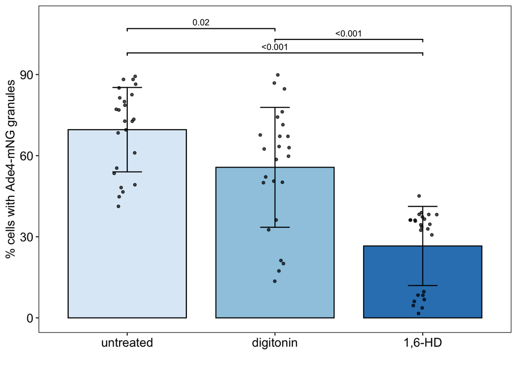

```r
# 検定結果のp値をマニュアルでアノテーションするのに必要なオブジェクトを作成。
annot1 = c("<0.001", "<0.001", "0.02")
y_position = c(98,103,107)
xmin = c(1, 2, 1)
xmax = c(3, 3, 2)

plot1 <- mean_sd %>% ggplot(aes(x= condition, y=mean))+
  geom_bar(aes(fill=condition), stat="identity",
           color="black",width = 0.8, position = position_dodge(width = 0.6)) + # colorは枠線の色、widthでバーの幅
  geom_signif(xmin = xmin, xmax =xmax, y_position =y_position,annotation = annot1, textsize = 3, tip_length = 0.01)+
  scale_fill_manual(values = c('#deebf7','#9ecae1','#3182bd'))+
  geom_errorbar(limits, width = 0.2, position = position_dodge(width = 0.6), size = 0.5) +
  geom_jitter(foci_stat, mapping=aes(x=condition, y= pct_foci_cell),size = 1,
              alpha=0.7, width = 0.1, height = 0)+
  ylab("% cells with Ade4-mNG granules") +   ## y軸のラベル
  xlab("")+                   ## x軸のラベル
  ylim(0,110)+                  ## y軸のレンジ
  theme( axis.title.y = element_text(size=12), axis.text.y = element_text(size=12,color = "black"),
         axis.title.x = element_text(size=12), axis.text.x = element_text(size=12,color = "black")
         ,legend.position = "none" #凡例を消す
         ,panel.border = element_rect(fill = NA, size = 0.5)# パネルを枠で囲む
         ,panel.background = element_blank()) #背景を白にする
plot1
```

# 6 正規性の検証

全てのデータが正規分布に従っていると仮定して統計検定を行ったが、プロットを見る限り、正規分布とは言い難い。そこでShapiro-Wilk検定でデータの正規性を検証する。

```r
# conditionの種類をベクトルとして取り出しておく
conds <- levels(foci_stat$condition)
# あるconditionの値に対応するpct_foci_cellの値の分布をshapiro.test()で検定するための関数を作成
st <- function(cond) {foci_stat %>%
  filter(condition == cond) %>%
  dplyr::select(pct_foci_cell) %>%
  as_vector() %>%
  shapiro.test()}
st("untreated") # 関数のテスト
```

```
##
##  Shapiro-Wilk normality test
##
## data:  .
## W = 0.90559, p-value = 0.02833
```

`lapply()`で`conds`の各要素を自作関数`st`に入力して、計算結果をリストにまとめて出力。

```r
st_result <- lapply(conds, st)
names(st_result) <- conds  # リストの要素の名前をつける
```

結果をテキストファイルに保存。

```r
sink("result_shapiro_test.txt")
for (cond in conds){   # st_resultの要素を順番にコンソールに表示
  print(st_result[cond])
}
```

```
## $untreated
##
##  Shapiro-Wilk normality test
##
## data:  .
## W = 0.90559, p-value = 0.02833
##
##
## $digitonin
##
##  Shapiro-Wilk normality test
##
## data:  .
## W = 0.93804, p-value = 0.1475
##
##
## $`1,6-HD`
##
##  Shapiro-Wilk normality test
##
## data:  .
## W = 0.7743, p-value = 8.729e-05
```

```r
sink()
```

検定の結果、`condition = digitonin`以外の群ではp値<0.05となり、正規性があるとは言えないことが示唆された。従って、ノンパラメトリックな手法で統計解析をやり直す。ノンパラメトリックな分散分析にはKruskal-Wallis検定を使用する。

```r
aov_kw <- kruskal.test(data = foci_stat, pct_foci_cell ~ condition)
sink("res_aov_kw.txt") # p<0.05よりグループ間に違いがあることを示唆
aov_kw
```

```
##
##  Kruskal-Wallis rank sum test
##
## data:  pct_foci_cell by condition
## Kruskal-Wallis chi-squared = 38.929, df = 2, p-value = 3.521e-09
```

```r
sink()
```

Tukey法のノンパラメトリック版としてSteel-Dwass testで多重比較する。`nparcomp`パッケージの`nparcomp()`を使用。

```r
res_sd <- foci_stat %>% nparcomp(pct_foci_cell ~ condition, data = .,
            asy.method = "mult.t",
             type = "Tukey",alternative = "two.sided", info = FALSE)
res_sd$Analysis$p.Value %>% signif(., digits = 3)  # p値の確認
```

```
## [1] 7.60e-02 0.00e+00 6.98e-06
```

```r
sink("result_sd_test.txt")
summary(res_sd)
```

```
##
##  #------------Nonparametric Multiple Comparisons for relative contrast effects----------#
##
##  - Alternative Hypothesis:  True relative contrast effect p is not equal to 1/2
##  - Estimation Method: Global Pseudo ranks
##  - Type of Contrast : Tukey
##  - Confidence Level: 95 %
##  - Method = Multi - T with 30 DF
##
##  - Estimation Method: Pairwise rankings
##
##  #---------------------------Interpretation--------------------------------------------#
##  p(a,b) > 1/2 : b tends to be larger than a
##  #-------------------------------------------------------------------------------------#
##
##  #----Data Info-------------------------------------------------------------------------#
##      Sample Size
## 1 untreated   24
## 2 digitonin   24
## 3    1,6-HD   25
##
##  #----Contrast--------------------------------------------------------------------------#
##                       untreated digitonin 1,6-HD
## digitonin - untreated        -1         1      0
## 1,6-HD - untreated           -1         0      1
## 1,6-HD - digitonin            0        -1      1
##
##  #----Analysis--------------------------------------------------------------------------#
##                   Comparison Estimator  Lower Upper   Statistic      p.Value
## 1 p( untreated , digitonin )     0.316  0.117 0.515   -2.317047 7.600358e-02
## 2    p( untreated , 1,6-HD )     0.003 -0.007 0.013 -122.549270 0.000000e+00
## 3    p( digitonin , 1,6-HD )     0.152  0.000 0.303   -5.756100 6.984006e-06
##
##  #----Overall---------------------------------------------------------------------------#
##   Quantile p.Value
## 1 2.506191       0
##
##  #--------------------------------------------------------------------------------------#
```

```r
sink()
```

再検定結果のp値をもとにアノテーションに必要なオブジェクトを作成。グラフを再度作成。

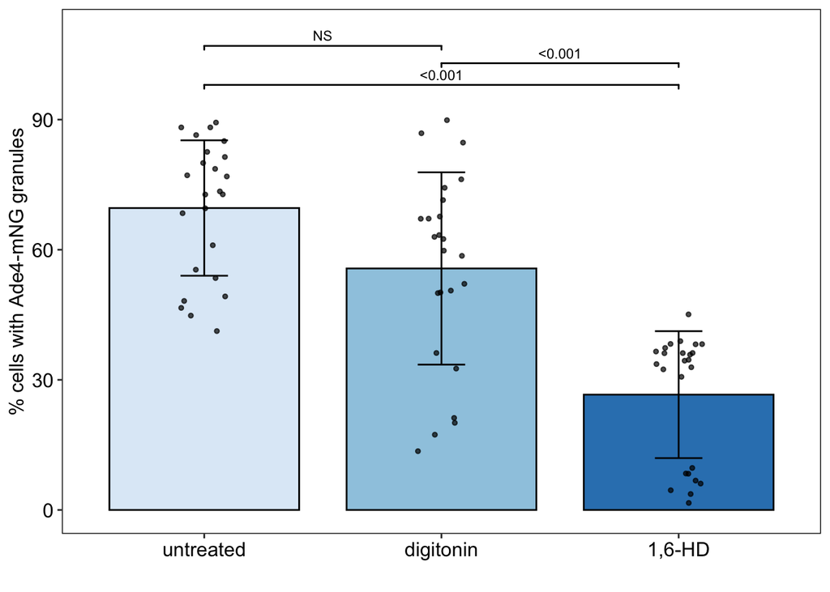

```r
annot2 = c("<0.001", "<0.001", "NS")
y_position = c(98,103,107)
xmin = c(1, 2, 1)
xmax = c(3, 3, 2)

plot2 <- mean_sd %>% ggplot(aes(x= condition, y=mean))+
  geom_bar(aes(fill=condition), stat="identity",
           color="black",width = 0.8, position = position_dodge(width = 0.6)) + # colorは枠線の色、widthでバーの幅
  geom_signif(xmin = xmin, xmax =xmax, y_position =y_position,annotation = annot2, textsize = 3, tip_length = 0.01)+
  scale_fill_manual(values = c('#deebf7','#9ecae1','#3182bd'))+
  geom_errorbar(limits, width = 0.2, position = position_dodge(width = 0.6), size = 0.5) +
  geom_jitter(foci_stat, mapping=aes(x=condition, y= pct_foci_cell),size = 1,
              alpha=0.7, width = 0.1, height = 0)+
  ylab("% cells with Ade4-mNG granules") +   ## y軸のラベル
  xlab("")+                   ## x軸のラベル
  ylim(0,110)+                  ## y軸のレンジ
  theme( axis.title.y = element_text(size=12), axis.text.y = element_text(size=12,color = "black"),
         axis.title.x = element_text(size=12), axis.text.x = element_text(size=12,color = "black")
         ,legend.position = "none" #凡例を消す
         ,panel.border = element_rect(fill = NA, size = 0.5)# パネルを枠で囲む
         ,panel.background = element_blank()) #背景を白にする
plot2
```

`geom_signif`内で比較するグループとアノテーションを指定することでも、p値を表すことができる。

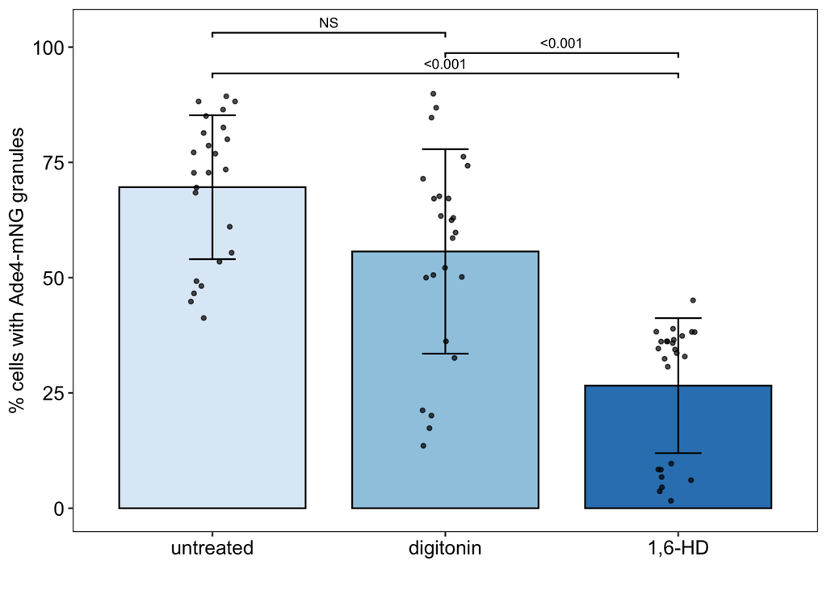

```r
# 比較するグループの指定
comparisons <- list(c("untreated", "1,6-HD"), c("digitonin", "1,6-HD"), c("untreated", "digitonin"))

plot3 <- mean_sd %>% ggplot(aes(x= condition, y=mean))+
  geom_bar(aes(fill=condition), stat="identity",
           color="black",width = 0.8, position = position_dodge(width = 0.6)) +
  # step_increaseは組み合わせのバーをどれだけずらすかの値
  geom_signif(comparisons = comparisons, step_increase = 0.05,
              annotations = annot2, textsize = 3, tip_length = 0.01) +

  scale_fill_manual(values = c('#deebf7','#9ecae1','#3182bd'))+
  geom_errorbar(limits, width = 0.2, position = position_dodge(width = 0.6), size = 0.5) +
  geom_jitter(foci_stat, mapping=aes(x=condition, y= pct_foci_cell),size = 1,
              alpha=0.7, width = 0.1, height = 0)+
  ylab("% cells with Ade4-mNG granules") +   ## y軸のラベル
  xlab("")+                   ## x軸のラベル
  # ylim(0,110)+                  ## y軸のレンジ
  theme( axis.title.y = element_text(size=12), axis.text.y = element_text(size=12,color = "black"),
         axis.title.x = element_text(size=12), axis.text.x = element_text(size=12,color = "black")
         ,legend.position = "none" #凡例を消す
         ,panel.border = element_rect(fill = NA, size = 0.5)# パネルを枠で囲む
         ,panel.background = element_blank()) #背景を白にする
plot3
```

# 7 入れ子データを使用した解析

上記では元データと要約統計量を別のデータフレームに格納して解析していた。tibbleと`nest()`を利用して、全てのデータを1つのtibbleにまとめて解析することを試みる。

```r
# 元データの用意
import_file_path_prom875 <- "prom_875"
csv_list_prom875 <- list.files(import_file_path_prom875, full.names = TRUE, pattern = "*.csv")
dat <- csv_list_prom875 %>%
  #「.」でcsv_listの位置を明示
  sapply(., read.csv, header =TRUE, sep = ",", stringsAsFactors = FALSE, simplify = FALSE) %>%
  bind_rows()
dat <- as_tibble(dat)  # tibble形式にしておく
dat <-
  dat %>%
  mutate(condition =case_when(
    str_detect(file_name, "hd") ~ "1,6-HD",
    str_detect(file_name, "digit") ~ "digitonin",
    TRUE ~ "untreated"))
dat$condition <- as_factor(dat$condition)
dat$condition <- fct_relevel(dat$condition, c("untreated", "digitonin", "1,6-HD"))
dat
```

```
## # A tibble: 73 × 8
##        X file_name  total_cell_number foci_cell pct_foci_cell prominence defocus
##    <int> <chr>                  <int>     <int>         <dbl>      <int> <lgl>
##  1     1 Ade4_mNG_…               327       164          50.2        875 NA
##  2     2 Ade4_mNG_…               337       228          67.7        875 NA
##  3     3 Ade4_mNG_…               312       271          86.9        875 NA
##  4     4 Ade4_mNG_…               306       275          89.9        875 NA
##  5     5 Ade4_mNG_…               281       238          84.7        875 NA
##  6     6 Ade4_mNG_…               283       190          67.1        875 NA
##  7     7 Ade4_mNG_…               281       168          59.8        875 NA
##  8     8 Ade4_mNG_…               284       180          63.4        875 NA
##  9     9 Ade4_mNG_…               329       119          36.2        875 NA
## 10    10 Ade4_mNG_…               310       111          35.8        875 NA
## # ℹ 63 more rows
## # ℹ 1 more variable: condition <fct>
```

`group_nest()`を使用して`condition`でグループ分けして、畳み込み。

```r
dat_nest <- dat %>%
  group_nest(condition)
dat_nest
```

```
## # A tibble: 3 × 2
##   condition               data
##   <fct>     <list<tibble[,7]>>
## 1 untreated           [24 × 7]
## 2 digitonin           [24 × 7]
## 3 1,6-HD              [25 × 7]
```

`pct_foci_cell`の平均とSDを計算。サンプルサイズの計算には`dplyr::n()`ではなく`nrow()`を使う。また視野内で観察した細胞数`total_cell_number`についても平均とSD、および合計を求めておく。

```r
dat_nest <- dat_nest %>%
mutate(mean = map_dbl(data, ~ mean(.$pct_foci_cell)),
         sd = map_dbl(data, ~ sd(.$pct_foci_cell)),
         N = map_int(data, ~ nrow(.)),
       cell_num_mean = map_dbl(data, ~ mean(.$total_cell_number)),
       cell_num_sd = map_dbl(data, ~ sd(.$total_cell_number)),
       cell_num_sum = map_int(data, ~ sum(.$total_cell_number)))
dat_nest %>%
  dplyr::select(-data) %>%
  kable(format ="markdown")
```

| condition | mean | sd | N | cell_num_mean | cell_num_sd | cell_num_sum |
| --- | --- | --- | --- | --- | --- | --- |
| untreated | 69.61400 | 15.60765 | 24 | 366.1250 | 229.72428 | 8787 |
| digitonin | 55.68350 | 22.16812 | 24 | 358.3333 | 149.28050 | 8600 |
| 1,6-HD | 26.58996 | 14.63313 | 25 | 359.9200 | 64.45342 | 8998 |

各サブデータの`pct_foci_cell`の分布に正規性があるかどうかを、Shapiro-Wilk検定で検証する。関数`shapiro.test()`を使用し、結果のリストを変数`swtest`に格納。さらにp値を取り出す。

```r
dat_nest <- dat_nest %>%
  mutate(swtest = map(data, ~ shapiro.test(.$pct_foci_cell)), # 返り値がリストなのでmapを使用
         sw_pval = map_dbl(swtest, ~.$p.value)) %>%
  dplyr::select(condition, mean:cell_num_sum, sw_pval, everything()) # 見やすいように列を並べ替える
dat_nest %>%
  dplyr::select(-data, -swtest) %>%
  kable(format = "markdown")
```

| condition | mean | sd | N | cell_num_mean | cell_num_sd | cell_num_sum | sw_pval |
| --- | --- | --- | --- | --- | --- | --- | --- |
| untreated | 69.61400 | 15.60765 | 24 | 366.1250 | 229.72428 | 8787 | 0.0283313 |
| digitonin | 55.68350 | 22.16812 | 24 | 358.3333 | 149.28050 | 8600 | 0.1475003 |
| 1,6-HD | 26.58996 | 14.63313 | 25 | 359.9200 | 64.45342 | 8998 | 0.0000873 |

p値<0.05となるconditionがあるため、正規性があるとは言えないことが示唆された。従ってノンパラメトリックな手法で統計解析する。ノンパラメトリックな分散分析にはKruskal-Wallis検定を使用する。サブデータ間の比較なのでdat_nestではなくdatそのものを使用するので省略。続いてノンパラメトリックなTukey検定であるSteel-Dwass多重検定もdatを使用するので省略。

`dat_nest`をExcelファイルに保存する際は、リスト列`data`を除去しないとエラーになる。

```r
dat_nest %>%
  dplyr::select(-data) %>%
  write.xlsx(., "nest_mean_sd.xlsx", colNames = TRUE, sheetName = "221027HD")
```

`dat_nest`だけを使用してデータをプロットする。`unnest(dat_nest, cols = data)`は`dat`と書いた方が簡単。

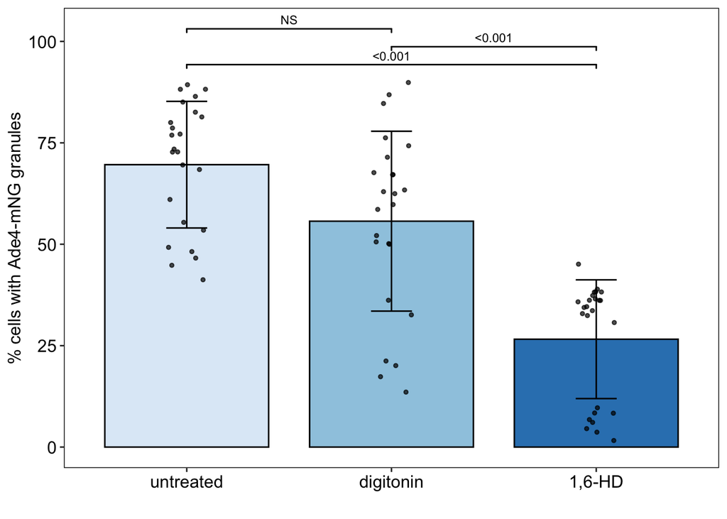

```r
annot2 = c("<0.001", "<0.001", "NS")
y_position = c(98,103,107)
xmin = c(1, 2, 1)
xmax = c(3, 3, 2)
comparisons <- list(c("untreated", "1,6-HD"), c("digitonin", "1,6-HD"), c("untreated", "digitonin"))

plot4 <- dat_nest %>%
  ggplot(aes(x= condition, y=mean))+
  geom_bar(aes(fill=condition), stat="identity",
           color="black",width = 0.8, position = position_dodge(width = 0.6)) +
  # step_increaseは組み合わせのバーをどれだけずらすかの値
  geom_signif(comparisons = comparisons, step_increase = 0.05,
              annotations = annot2, textsize = 3, tip_length = 0.01) +
  scale_fill_manual(values = c('#deebf7','#9ecae1','#3182bd'))+
  geom_errorbar(aes(ymax = mean + sd, ymin = mean - sd), width = 0.2, position = position_dodge(width = 0.6), size = 0.5) +
  geom_jitter(unnest(dat_nest, cols = data), mapping=aes(x=condition, y= pct_foci_cell),size = 1,
  alpha=0.7, width = 0.1, height = 0)+
  ylab("% cells with Ade4-mNG granules") +   ## y軸のラベル
  xlab("")+                   ## x軸のラベル
  # ylim(0,110)+                  ## y軸のレンジ
  theme( axis.title.y = element_text(size=12), axis.text.y = element_text(size=12,color = "black"),
         axis.title.x = element_text(size=12), axis.text.x = element_text(size=12,color = "black")
         ,legend.position = "none" #凡例を消す
         ,panel.border = element_rect(fill = NA, size = 0.5)# パネルを枠で囲む
         ,panel.background = element_blank()) #背景を白にする
plot4
```